# miniProject_income

## 지역별 연령대 비율 시각화

```r
ageCut_by_region <- welfare %>%
  group_by(code_region, ageCut2) %>%
  summarise(n=n()) %>%
  mutate(tot_group = sum(n)) %>%
  mutate(pct = round(n/tot_group*100,2))
```

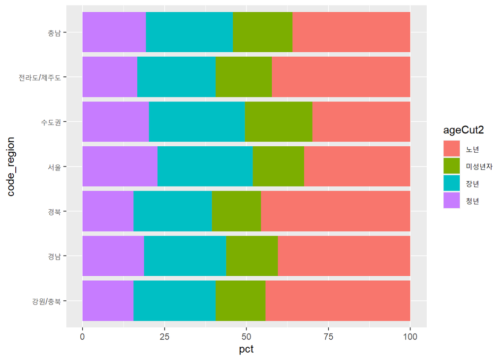

```r
# ageCut_by_region


ggplot(data = ageCut_by_region,
       aes(x=code_region, y=pct, fill=ageCut2))+
  geom_col()+
  coord_flip()
```

## => 비수도권일수록 노년의 비율이 커지는걸 볼 수 있다.

## 지역별 월급

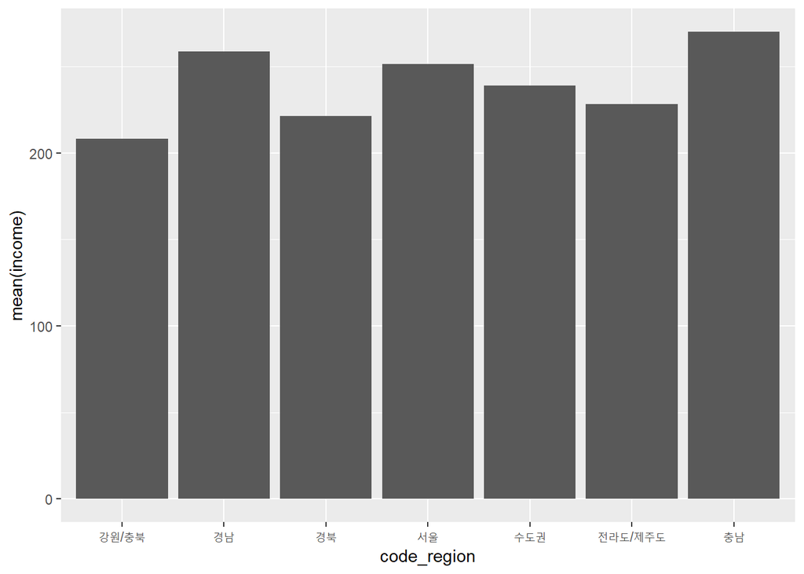

```r
income_by_region <- welfare %>%
  filter(!is.na(income)) %>%
  group_by(code_region) %>%
  summarise(mean(income))

# income_by_region

ggplot(data=income_by_region,
       aes(x=code_region, y=`mean(income)`))+geom_col()
```

## => 서울의 월급이 가장 높을줄 알았는데 의외로 충남의 월급이 가장 높았다..

## 직종코드 기반 급여를 많이 받거나 적게 받는 직종 30개씩 검색

```r
sum(is.na(welfare$code_job)) # 결측치 9135개
```

```
## [1] 9135
```

```r
# table(welfare$code_job)

income_by_job <- welfare %>%
  filter(!is.na(income)) %>%
  group_by(code_job) %>%
  summarise(meanIncome = mean(income)) %>%
  arrange(desc(meanIncome)) %>%
  head(30)
job_top30 <- as.data.frame(income_by_job)
job_top30
```

```
##    code_job meanIncome
## 1       233   845.0667
## 2       241   843.6429
## 3       111   750.0000
## 4       132   726.1800
## 5       742   572.4067
## 6       120   563.7633
## 7       134   557.4667
## 8       131   549.9125
## 9       141   535.8056
## 10      831   531.6600
## 11      232   527.6800
## 12      235   508.8056
## 13      272   503.4560
## 14      871   495.8000
```

[output cut: 16 more lines]

```r
income_by_job2 <- welfare %>%
  filter(!is.na(income)) %>%
  group_by(code_job) %>%
  summarise(meanIncome = mean(income)) %>%
  arrange((meanIncome)) %>%
  head(30)

job_bot30 <- as.data.frame(income_by_job2)
job_bot30
```

```
##    code_job meanIncome
## 1       951   80.16648
## 2       620   83.33000
## 3       999   88.22101
## 4       941   88.78775
## 5       242   89.00000
## 6       611   92.00000
## 7       991  101.58125
## 8       421  103.52643
## 9       952  107.84511
## 10      953  116.82203
## 11      429  121.78333
## 12      942  133.72326
## 13      442  135.70500
## 14      612  140.58000
```

[output cut: 16 more lines]

```r
# jobName
jobTop30 <- as.list(job_top30[1])
jobTop30
```

```
## $code_job
##  [1]  233  241  111  132  742  120  134  131  141  831  232  235  272  871  237
## [16]  223 1011  149  221  271  853  211  152  752  854  411  236  224  213  320
```

```r
class(jobTop30)
```

```
## [1] "list"
```

```r
jobBot30 <- as.list(job_bot30[1])
jobBot30
```

```
## $code_job
##  [1] 951 620 999 941 242 611 991 421 952 953 429 942 442 612 722 314 992 259 422
## [20] 930 441 423 521 247 392 710 254 721 246 284
```

## 월급이 많은 상위 30개의 직업 이름

```r
for (i in jobTop30$code_job){
  print(jobName[jobName["code_job"]==i,]$job)
  # print(i)

}
```

```
## [1] "금속 재료 공학 기술자 및 시험원"
## [1] "의료진료 전문가"
## [1] "의회의원 고위공무원 및 공공단체임원"
## [1] "보험 및 금융 관리자"
## [1] "제관원 및 판금원"
## [1] "행정 및 경영지원 관리자"
## [1] "문화 예술 디자인 및 영상 관련 관리자"
## [1] "연구 교육 및 법률 관련 관리자"
## [1] "건설 전기 및 생산 관련 관리자"
## [1] "석유 및 화학물 가공장치 조작원"
## [1] "화학공학 기술자 및 시험원"
## [1] "전기 전자 및 기계 공학 기술자 및 시험원"
## [1] "금융 및 보험 전문가"
## [1] "철도 및 전동차 기관사"
## [1] "항공기 선박 기관사 및 관제사"
## [1] "정보 시스템 운영자"
## [1] "장교"
## [1] "기타 건설 전기 및 생산 관련 관리자"
## [1] "컴퓨터 하드웨어 및 통신공학 전문가"
## [1] "인사 및 경영 전문가"
## [1] "자동조립라인 및 산업용 로봇 조작원"
## [1] "생명 및 자연 과학 관련 전문가"
## [1] "고객서비스 관리자"
## [1] "운송장비 정비원"
## [1] "운송차량 및 기계 관련 조립원"
## [1] "경찰 소방 및 교도 관련 종사자"
## [1] "안전 관리 및 검사원"
## [1] "통신 및 방송송출 장비 기사"
## [1] "생명 및 자연 과학 관련 시험원"
## [1] "금융 및 보험관련 사무 종사자"
```

```r
for (i in jobBot30$code_job){
  print(jobName[jobName["code_job"]==i,]$job)
  # print(i)

}
```

```
## [1] "가사 및 육아 도우미"
## [1] "임업관련 종사자"
## [1] "기타 서비스관련 단순 종사원"
## [1] "청소원 및 환경 미화원"
## [1] "약사 및 한약사"
## [1] "작물재배 종사자"
## [1] "농립어업관련 단순 종사원"
## [1] "의료 복지 관련 서비스 종사자"
## [1] "음식관련 단순 종사원"
## [1] "판매관련 단순 종사원"
## [1] "기타 이미용 예식 및 의료보조 서비스 종사자"
## [1] "경비원 및 검표원"
## [1] "음식서비스 종사자"
## [1] "원예 및 조경 종사자"
## [1] "의복 제조관련 기능 종사자"
## [1] "비서 및 사무 보조원"
## [1] "계기검침 수금 및 주차 관련 종사원"
## [1] "기타 교육 전문가"
## [1] "이 미용 및 관련 서비스 종사자"
## [1] "제조관련 단순 종사원"
## [1] "주방장 및 조리사"
## [1] "혼례 및 장례 종사자"
## [1] "매장 판매 종사자"
## [1] "사회복지관련 종사자"
## [1] "여행 안내 및 접수 사무원"
## [1] "식품가공관련 기능 종사자"
## [1] "문리 기술 및 예능 강사"
## [1] "섬유 및 가죽 관련 기능 종사자"
## [1] "보건의료관련 종사자"
## [1] "화가 사진가 및 공연예술가"
```

## 직종코드는 있지만, 급여가 확인되지 않은 3000명 정도 NA가 존재

## 급여가 NA인 사람의 직종코드를 참조하여, 동일한 직종코드의 해당되는

## 다른 사람들의 데이터를 찾아서 급여를 유추하여 결측치 대체

```r
welfare <- welfare %>%
  mutate(index = rownames(welfare))

# 직종코드 o / 급여 NA인 직종코드

list_a <- welfare[is.na(welfare$income)&!is.na(welfare$code_job),][c("code_job")]
# list_a

list_a[,"income"] <- c(NA)
# list_a

# 직종코드 중복값 제외
unique_a <- unique(list_a$code_job)
unique_a
```

```
##   [1] 530 286 521 773 951 274 151 772 991 399 254 875 873 930 941 422 222 910
##  [19] 762 999 761 952 721 799 942 281 442 441 823 159 874 241 141 620 135 811
##  [37] 842 741 611 953 751 259 792 522 780 510 922 235 231 247 221 283 152 432
##  [55] 722 312 862 421 730 211 854 313 921 149 851 822 429 771 743 821 285 613
##  [73] 612 899 753 248 431 131 224 120 153 284 132 710 992 133 234 892 630 864
##  [91] 774 271 852 841 272 242 314 423 791 139 812 881 819 253 245 251 261
```

```r
length(unique_a) # 107개
```

```
## [1] 107
```

```r
# 모든 직업들의 평균 월급을 저장

income_by_alljob <- welfare %>%
  filter(!is.na(income)) %>%
  group_by(code_job) %>%
  summarise(meanIncome = mean(income))

income_by_alljob
```

```
## # A tibble: 142 x 2
##    code_job meanIncome
##       <dbl>      <dbl>
##  1      111       750
##  2      120       564.
##  3      131       550.
##  4      132       726.
##  5      133       375.
##  6      134       557.
##  7      135       323.
##  8      139       317.
##  9      141       536.
## 10      149       465.
## # ... with 132 more rows
```

```r
# 직업코드에 맞는 평균 월급을 저장

for (i in unique_a){
  if (i %in% income_by_alljob$code_job){
    list_a[list_a$code_job==i,]$income=income_by_alljob[income_by_alljob$code_job==i,]$meanIncome
    print(i)
  }
}
```

```
## [1] 530
## [1] 286
## [1] 521
## [1] 773
## [1] 951
## [1] 274
## [1] 151
## [1] 772
## [1] 991
## [1] 399
## [1] 254
## [1] 875
## [1] 873
## [1] 930
## [1] 941
```

[output cut: 89 more lines]

```r
list_a[is.na(list_a$income),]
```

```
##       code_job income
## 5833       630     NA
## 5834       630     NA
## 8200       630     NA
## 9262       812     NA
## 9522       819     NA
## 9523       819     NA
## 10486      630     NA
## 10669      630     NA
## 10939      630     NA
## 10940      630     NA
## 10948      630     NA
## 10949      630     NA
## 11067      630     NA
## 11225      630     NA
## 11226      630     NA
## 11227      630     NA
## 11238      630     NA
## 11384      819     NA
## 11385      819     NA
## 12078      630     NA
## 12079      630     NA
## 12649      630     NA
## 14930      819     NA
## 15048      630     NA
## 15087      819     NA
## 15254      630     NA
## 15321      630     NA
```

```r
# -> 직업코드가 630, 812, 819인 직업들의 income이 없음

welfare %>%
  filter(!is.na(income)&code_job==819) %>%
  summarise(mean(income))
```

```
##   mean(income)
## 1          NaN
```

## 630, 812, 819번의 직업코드들은 income데이터가 아예없어서 대체 불가능!!!

```r
# welfare 데이터프레임에 630, 812, 819 코드를 제외한 값을 넣어주자

for (i in c(1:nrow(list_a))){
  welfare[row.names(list_a[i,]),]$income <- list_a[i,2]
}
```

[output not shown]